- **Title: Working example 1**
- **Output: html_document**
- **Reference: A guide to test association between Polygenic Risk Scores and psychological and psychiatric traits: practical examples**
- **Authors: Itziar Irigoien, Patricia Mas, Sergi Papiol, Neus Barrantes-Vidal, Araceli Rosa, and Concepción Arenas**

## Working example 1

- **In this example we simulate 9 PRSs, and a continuous trait, with gender, clinical diagnosis (with 2 categories), age, and two Principal Components as covariates**
- **data reading**

```r
dat <- read.table("WExample1.csv", header=TRUE, sep=";", dec=",")
names(dat) #
```

```
##  [1] "Sex"        "Diagnostic" "Age"        "Trait"      "PRS.1"
##  [6] "PRS.2"      "PRS.3"      "PRS.4"      "PRS.5"      "PRS.6"
## [11] "PRS.7"      "PRS.8"      "PRS.9"      "PC1"        "PC2"
```

- **do not forget to declare the categorical variables as factors**

```r
dat$Sex <- as.factor(dat$Sex)
dat$Diagnostic <- as.factor(dat$Diagnostic)
```

## 1. What full model should be considered?

- **First, given a particular PRS (named PRS.i), consider all the possible full models:**
- **FMW I : Trait versus PRS.i + Sex + Diagnostic + Age + PC1 + PC2**
- **FMSex: Trait versus PRS.i + Sex + PRS.i,Sex + Diagnostic + Age + PC1 + PC2**
- **FMDiagnostic: Trait versus PRS.i + Sex + Diagnostic + PRS.i ,Diagnostic + Age + PC1 + PC2**
- **FMSex/Diagnostic: Trait versus PRS.i + Sex + PRS.i,Sex + Diagnostic + PRS.i,Diagnostic + Age + PC1 + PC2**

## 2. How to make a PRS ranking to find the important ones?

- **As is described in the paper, for each model, calculate the coefficient of determination $R^2$ and calculate the sum: $S = R^2_{WI} + R^2_{Sex} + R^2_{Diagnostic} + R^2_{Sex*Diagnostic}$.**
- **According to S, list the PRSs in decreasing order:**
- **Order the PRSs**

```r
out <- orderR2(dat, yname="Trait", prsname = "PRS.")
head(out)
```

```
##           Model1     Model2     Model3     Model4       Sum
## PRS.4 0.06561329 0.07420427 0.12600084 0.15146070 0.4172791
## PRS.6 0.05596966 0.06220536 0.13638253 0.15759204 0.4121496
## PRS.2 0.04973955 0.05309214 0.11850006 0.12356753 0.3448993
## PRS.5 0.05308815 0.06728312 0.10264612 0.11770778 0.3407252
## PRS.8 0.07995274 0.08034903 0.08088220 0.08141782 0.3226018
## PRS.9 0.07932875 0.08028067 0.07933969 0.08030066 0.3192498
```

```r
write.csv2(out,file="WExample1_Ordered_PRS.csv")
```

- **Plot the sum of coefficients of determination $S_{R^2}$. Lines: in blue the median; in black the mean**

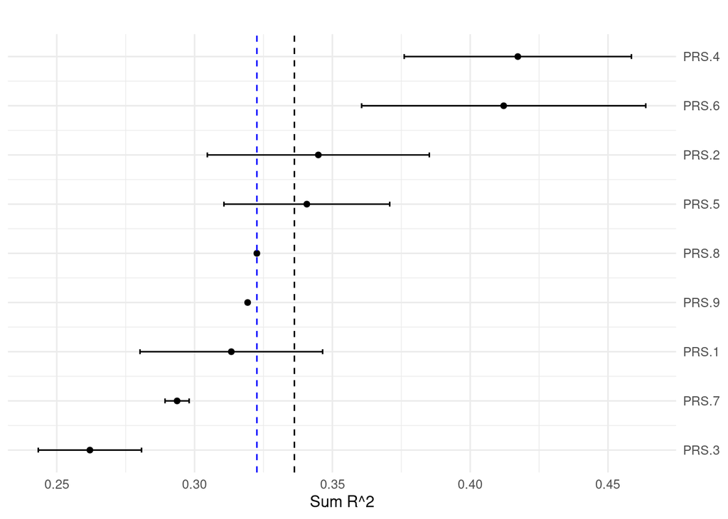

```r
out <- data.frame(out)
nPRS <- dim(out)[1]
select <- grep("Model", names(out), value=FALSE)
out$effect <- out$Sum
sds <- apply(out[, select], 1, sd)
out$lower <- out$effect - sds
out$upper <- out$effect + sds
out$rank <- nPRS:1

n <- dim(out)[1]
ggplot(data=out, aes(y=rank, x=effect, xmin=lower, xmax=upper)) +
  geom_point() +
  geom_errorbarh(height=.1) +
  scale_y_continuous(name=NULL, breaks= n:1, labels=row.names(out), position="right") +
  labs(title='', x='Sum R^2', y = 'PRS') +
  geom_vline(xintercept=mean(out$effect), color='black', linetype='dashed') +
  geom_vline(xintercept=median(out$effect), color='blue', linetype='dashed') +
  theme_minimal()
```

- **According to the obtained results, first, PRS.4 is selected to analyse its possible association with the Trait.**

## 3. Which model, of all the possible ones, should be used?

- **The following Figure represents the scatter plot of Trait versus PRS.4 separated by Sex and Diagnostic groups.**

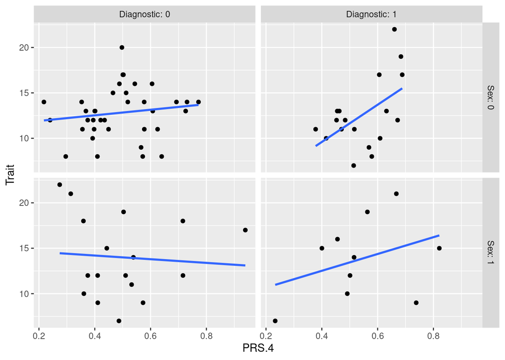

```r
# First candidate PRS.4
# Plot it
ggplot(dat, aes(x=PRS.4, y=Trait)) +
  geom_point() +
  geom_smooth(method=lm, se=FALSE)+
  facet_grid(Sex ~ Diagnostic, labeller=label_both)
```

## 4. For a continuous trait, what steps should be followed for a correct analysis?

- **4.1. How is the candidate model validated?**
- **First, we validate the normality of the errors and the constant variance conditions (see the figures and the results of Shapiro test and Levene test.**

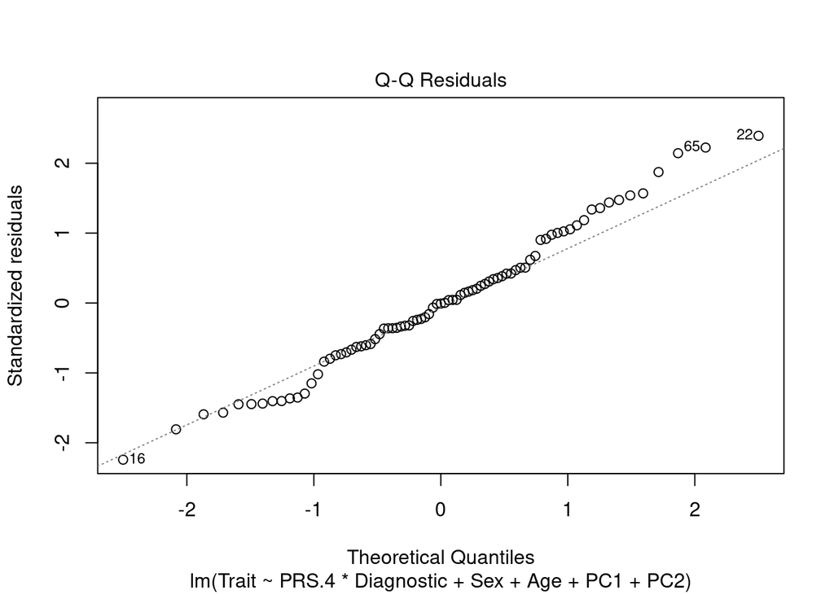

```r
#model
FM <- lm(Trait ~ PRS.4*Diagnostic + Sex + Age + PC1 + PC2, data=dat)
#qq-plot for normality
plot(FM,2)
```

```r
#Shapiro-Wilk test
shapiro.test(FM$residuals)
```

```
##
##  Shapiro-Wilk normality test
##
## data:  FM$residuals
## W = 0.98413, p-value = 0.4166
```

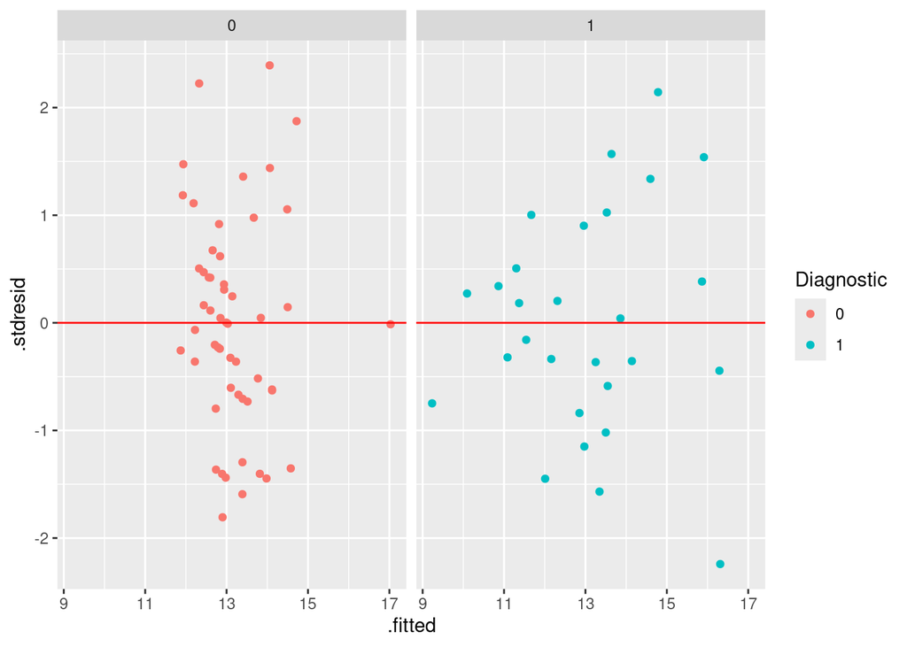

```r
#plot for variances
d <- fortify(FM)
ggplot(d,aes(x=.fitted, y=.stdresid, colour=Diagnostic)) + geom_point() + geom_hline(yintercept=0, col="red")+
  facet_wrap(.~Diagnostic)
```

```r
#Levene's test
leveneTest(.stdresid ~ Diagnostic, data=d)
```

```
## Levene's Test for Homogeneity of Variance (center = median)
##       Df F value Pr(>F)
## group  1  0.1193 0.7307
##       79
```

-**Having the full model validated, we can use it.**

- **4.3 How a possible association is established?**

```r
summary(FM)
```

```
##
## Call:
## lm(formula = Trait ~ PRS.4 * Diagnostic + Sex + Age + PC1 + PC2,
##     data = dat)
##
## Residuals:
##     Min      1Q  Median      3Q     Max
## -7.3117 -2.1180 -0.0277  1.6987  7.9418
##
## Coefficients:
##                   Estimate Std. Error t value Pr(>|t|)
## (Intercept)       14.81613    2.80605   5.280 1.28e-06 ***
## PRS.4             -1.04058    3.71031  -0.280   0.7799
## Diagnostic1       -8.32066    3.62154  -2.298   0.0245 *
## Sex1               1.29952    0.83922   1.548   0.1258
## Age               -0.07070    0.08635  -0.819   0.4156
## PC1                0.92650    6.45497   0.144   0.8863
## PC2                8.03272    6.22984   1.289   0.2013
## PRS.4:Diagnostic1 15.02560    6.69040   2.246   0.0277 *
## ---
## Signif. codes:  0 '***' 0.001 '**' 0.01 '*' 0.05 '.' 0.1 ' ' 1
##
## Residual standard error: 3.541 on 73 degrees of freedom
## Multiple R-squared:  0.126,  Adjusted R-squared:  0.04219
## F-statistic: 1.503 on 7 and 73 DF,  p-value: 0.1796
```

**where Sex takes values 0 or 1, depending on whether the individual under study is male or female, affecting only the value of the intercept.**

-**However, if the objective is to evaluate the possible association between Trait and PRS.4, it can be interesting to check whether the respective PRS.4 coefficients under each Diagnostic group are considerable or not. Note that these coefficients vary according to the Diagnosis group being b1 for the Diagnostic group 0, which has been taken as the basal group; b1 + b7 for the Diagnostic 1**

```r
summary(glht(FM, "PRS.4 = 0"))
```

```
##
##   Simultaneous Tests for General Linear Hypotheses
##
## Fit: lm(formula = Trait ~ PRS.4 * Diagnostic + Sex + Age + PC1 + PC2,
##     data = dat)
##
## Linear Hypotheses:
##            Estimate Std. Error t value Pr(>|t|)
## PRS.4 == 0   -1.041      3.710   -0.28     0.78
## (Adjusted p values reported -- single-step method)
```

```r
summary(glht(FM, "PRS.4  + PRS.4:Diagnostic1 = 0"))
```

```
##
##   Simultaneous Tests for General Linear Hypotheses
##
## Fit: lm(formula = Trait ~ PRS.4 * Diagnostic + Sex + Age + PC1 + PC2,
##     data = dat)
##
## Linear Hypotheses:
##                                Estimate Std. Error t value Pr(>|t|)
## PRS.4 + PRS.4:Diagnostic1 == 0    13.98       5.55    2.52   0.0139 *
## ---
## Signif. codes:  0 '***' 0.001 '**' 0.01 '*' 0.05 '.' 0.1 ' ' 1
## (Adjusted p values reported -- single-step method)
```

-**That means that for Diagnostic group 0 there is no relevant association (coeff = -1.041), but for Diagnostic group 1, the association is strong, positive (coeff = 13.980), and significant (p-value = 0.014).**

-**Last step: We move to the next PRS.**